# Understanding the Enrollment Rate Drop in Key Account Motion

Joyvalerie Mondejar**, **Nikko Joe Ramal

February 11, 2019

*Last updated: February 06, 2019*

# Introduction

UHG has been developing a number of motion programs catered to the different segments of its members. Monthly motion reports, which provides among others current and past year month enrollment and participations statistics have been circulating within UHC. It has been noticed in these reports that although the number of enrolled members in the motion programs has increased in general (both employer and individual accounts) between 2017 and 2018, there was a substantial drop in the enrollment rate for the Key Accounts Motion from 64% in July 2017 down to 42% in July 2018. Also, there was a considerable drop in the active rate among these enrolled members from 61.9% in July 2017 down to 44.3% in July 2018. We think that this might be connected to the shift from bulk-shipping devices to employers to directly shipping devices to members’ homes that happened sometime between December 2017 and January 2018.

With these findings, it is important to establish and understand the characteristics that exist between the members in July 2017 and in July 2018 to better guide the future motion enrollment and engagement efforts. Through this grant, we would like to compare the member characteristics, particularly those related to health between those 1) eligible, 2) enrolled, and 3) actively walking among those enrolled in July 2017 and in July 2018.

# Methods

This grant used the UHC pharmacy, medical claims, and motion data for Key Account motion eligible members. There are two groups that were compared, namely, those members of employers eligible for Key Account motion program in July 2017 (Group 1) and those that were eligible in July 2018 (Group 2). The monthly data going back to one year prior of the current year month were also gathered. For consistency, the researchers have used the same definitions of eligible, enrolled, and active as in the monthly motion report, i.e., had at least one day with at least 100 steps in the month, and did not have an incentive adjustment < $40 during the month. The researchers conducted several analyses to examine the differences between enrolled members in July 2018 compared to those enrolled in July 2017.

**Data cleaning done**

- Those individuals not enrolled in UHC plan were removed.
- Row records which do not belong to either groups were removed.
- Members not associated with Key Account motion were also removed.
- We also suspected that members younger than 18 years old are not eligible to Key Account motion program.
- Duplicates were removed.
- Gender that were ‘U’ were converted to NAs.
- Median household income that is 0 were converted to NAs.
- RAF scores that were 0 were converted to NAs.
- Missing or negative allowed amounts were replaced with 0.

Numerical variables such as age, median household income, RAF score, and allowed amounts were compared using independent-samples t-test between the two groups. Categorical variables such as gender, subscriber indicator, area of residence, condition diagnoses were compared using chi-squared test between the two groups. If the proportions are significantly different between the two groups, the size of the difference is quantified using Cohen’s h. Hedges’ g was used to quantify the effect size of statistically different means between the two groups. The allowed amounts were adjusted for inflation in 2018.

# Results

To better understand the enrollment drop in Key Accounts Motion, we examined the differences of eligible, enrolled and active among eligible and enrolled members between July 2017 and July 2018. We compared these groups with regard to patient demographics, certain disease conditions, and healthcare costs.

## Eligibility and Enrollment

Key Account motion enrollment rate dropped from 69.1% in July 2017 down to 45.8% in July 2018. There are discrepancies in the counts of eligible members as well as the enrolled members largely because the monthly motion report included those members who were not enrolled with any UHG plan and those that were not eligible to Key Account motion, i.e., either associated with small business or public accounts. The reason being was that some of the individual’s identity from the AWS motion data did not match with the PHI of individuals from NGIS.

| Table 1. Enrollment rate Year_Mo | Table 1. Enrollment rate Eligible | Table 1. Enrollment rate Enrolled | Table 1. Enrollment rate % |
| --- | --- | --- | --- |
| Group 1 |  |  |  |
| 201707 | 14071 | 9730 | 69.1 |
| Group 2 |  |  |  |
| 201807 | 36438 | 16672 | 45.8 |

The spike in the figure below shows that more than half of the employers in July 2018 having employees did not enroll at all and less percentage of employers having most of their employees enrolled in KA motion program. The spike at zero could be addressed at the admin level of the companies while the waning middle distribution could be addressed at the employees level making sure that the corresponding addresses are updated.

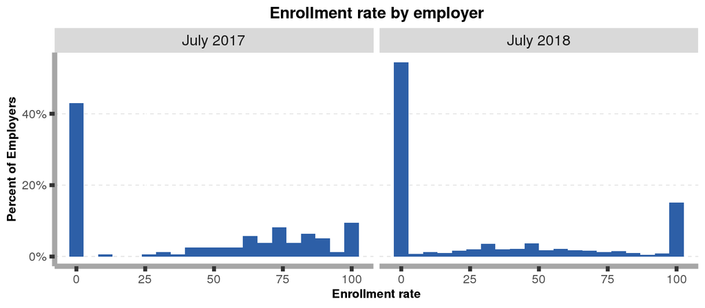

$\hspace{0in}$ Figure 1. Enrollment rate by employer

There were 7,747 eligible members in July 2017 that were still eligible in July 2018 and there were 5,728 members enrolled in both year months.

## Eligible

### Demographics

Table 2 shows that the eligible members in July 2018 aree a year younger than those eligible in July 2017. However, this is a negligible difference. Eligible members in July 2018 have 4% more females than in July 2017. There are more who live in suburban areas and less in rural areas among the July 2018 eligible members. The household median income of eligible members in July 2018 is $1,047 more than the income of eligible members in July 2017. The effect size is 0.044, a negligible estimate.

Table 2. Demographics profile of those who were eligible for Key Account motion program

|  | July 2017 (N=14071) | July 2018 (N=36438) | p value |
| --- | --- | --- | --- |
| **Age** |  |  | < 0.001 |
| Median (Q1, Q3) | 44.00 (35.00, 54.00) | 43.00 (33.00, 54.00) |  |
| Mean (SD) | 44.58 (11.89) | 43.57 (12.12) |  |
| Range | 19.00 - 85.00 | 18.00 - 94.00 |  |
| **Gender** |  |  | < 0.001 |
| N-Miss | 0 | 7 |  |
| F | 6556 (46.6%) | 18593 (51.0%) |  |
| M | 7515 (53.4%) | 17838 (49.0%) |  |
| **Subscriber** | 11177 (79.4%) | 28770 (79.0%) | 0.237 |
| **Area** |  |  | < 0.001 |
| N-Miss | 30 | 47 |  |
| U | 4364 (31.1%) | 11839 (32.5%) |  |
| S | 6017 (42.9%) | 16790 (46.1%) |  |
| R | 3660 (26.1%) | 7762 (21.3%) |  |
| **Median Household Income** |  |  | < 0.001 |
| N | 14037 | 36375 |  |
| N-Miss | 34 | 63 |  |
| Median (Q1, Q3) | 56028.00 (44167.00, 73602.00) | 57015.00 (44583.00, 75077.00) |  |
| Mean (SD) | 61004.91 (23145.73) | 62052.30 (23935.88) |  |
| Range | 11021.00 - 217171.00 | 11021.00 - 250001.00 |  |

Table 3. Effect size of the difference

| Variable | Observed difference (%) | Estimate | Magnitude |
| --- | --- | --- | --- |
| Female | 4.44 | 0.089 | negligible |
| Suburban | 3.28 | 0.066 | negligible |
| Rural | 4.74 | 0.112 | negligible |

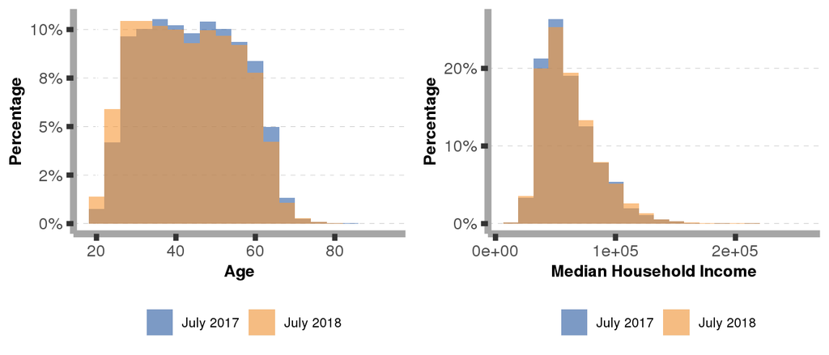

$\hspace{0in}$ Figure 2. Distribution of age and median household income

### Health

Table 4 shows that the prevalence of disease conditions do not differ between the two groups, but the the RAF scores seems to be different. On the average, the RAF scores of July 2018 eligible members is lower by 16.3 % than those of July 2017 eligible members. The effect size is 0.055, a negligible estimate.

Table 4. RAF score and percentage prevalence between eligible members

|  | July 2017 (N=14071) | July 2018 (N=36438) | p value |
| --- | --- | --- | --- |
| **Type 2 Diabetes** | 80 (0.6%) | 194 (0.5%) | 0.620 |
| **Hypertension** | 392 (2.8%) | 1052 (2.9%) | 0.541 |
| **Depression / Anxiety** | 246 (1.7%) | 695 (1.9%) | 0.236 |
| **COPD** | 21 (0.1%) | 55 (0.2%) | 0.965 |
| **CHF** | 12 (0.1%) | 37 (0.1%) | 0.599 |
| **RA** | 5 (0.0%) | 15 (0.0%) | 0.775 |
| **Chronic Pain** | 498 (3.5%) | 1327 (3.6%) | 0.580 |
| **RAF Score** |  |  | < 0.001 |
| N-Miss | 0 | 7 |  |
| Median (Q1, Q3) | 0.49 (0.29, 0.73) | 0.49 (0.29, 0.70) |  |
| Mean (SD) | 1.29 (4.37) | 1.08 (3.56) |  |
| Range | 0.14 - 185.14 | 0.14 - 185.14 |  |

To make more sense of the RAF scores as a measure of health status, we considered only those eligible members that were continuously enrolled with UHC plan for 13 months. Interestingly, there is no significant difference between the RAF scores of those continuously enrolled between the two groups.

Table 5. RAF score of UHC continuously enrolled between eligible members

|  | July 2017 (N=865) | July 2018 (N=7628) | p value |
| --- | --- | --- | --- |
| **RAF Score** |  |  | 0.820 |
| Median (Q1, Q3) | 0.48 (0.29, 0.70) | 0.55 (0.29, 0.73) |  |
| Mean (SD) | 1.33 (3.87) | 1.37 (4.62) |  |
| Range | 0.14 - 54.55 | 0.14 - 185.14 |  |

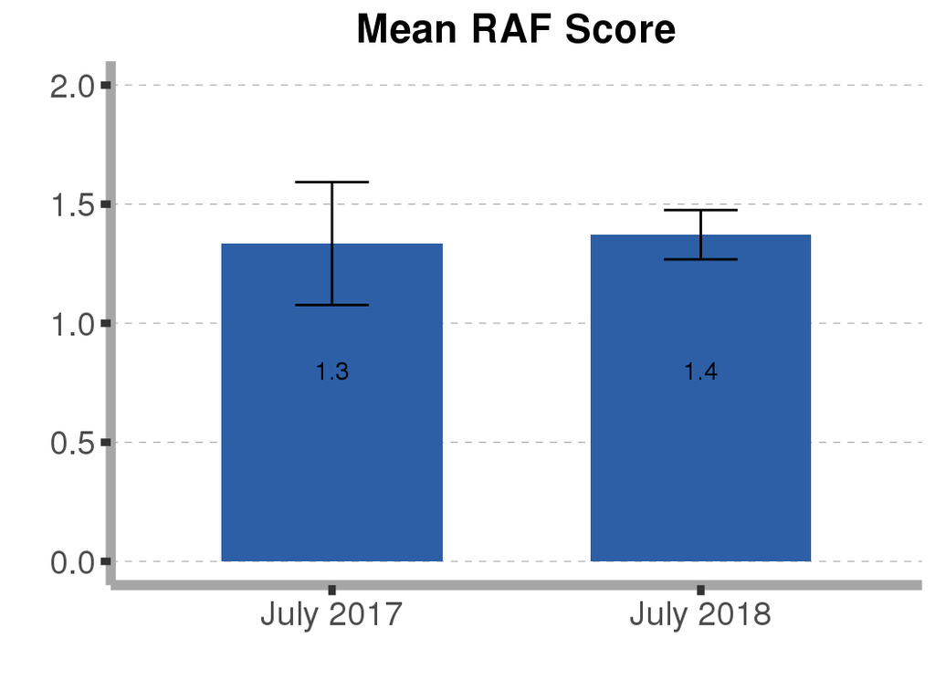

$\hspace{0in}$ Figure 3. Mean (confidence interval) of RAF score

To examine the disease prevalence further, continuous UHC plan enrollment from January to July of the corresponding year was considered. The prevalence of diseases still do not significantly differ between the two groups.

Table 6. Jan - July percentage prevalence

|  | July 2017 (N=14071) | July 2018 (N=36438) | p value |
| --- | --- | --- | --- |
| **T2D_Flag** | 80 (0.6%) | 194 (0.5%) | 0.620 |
| **Hypertension_Flag** | 1377 (9.8%) | 3657 (10.0%) | 0.400 |
| **Dep_Anx_Flag** | 868 (6.2%) | 2416 (6.6%) | 0.059 |
| **COPD_Flag** | 79 (0.6%) | 188 (0.5%) | 0.527 |
| **CHF_Flag** | 39 (0.3%) | 93 (0.3%) | 0.665 |
| **RA_Flag** | 18 (0.1%) | 43 (0.1%) | 0.774 |
| **ChronicPain_Flag** | 1515 (10.8%) | 4002 (11.0%) | 0.485 |

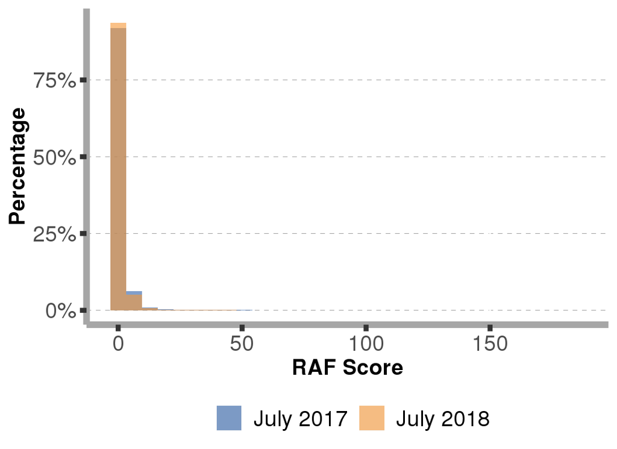

$\hspace{0in}$ Figure 4. RAF score distribution

### Claims

On the average, table 7 shows that the eligible members in July 2018 have around $8 higher costs for doctor visits. However, the effect size in the Table 8 suggests that this difference is negligible.

Table 7. Comparison of healthcare $ spending

|  | July 2017 (N=14071) | July 2018 (N=36438) | p value |
| --- | --- | --- | --- |
| **IP** |  |  | 0.580 |
| Mean (SD) | 113.37 (2392.77) | 100.92 (2215.64) |  |
| Range | 0.00 - 167765.80 | 0.00 - 135134.21 |  |
| **OP** |  |  | 0.211 |
| Mean (SD) | 103.93 (893.53) | 117.93 (1204.90) |  |
| Range | 0.00 - 22388.46 | 0.00 - 47591.66 |  |
| **DR** |  |  | 0.041 |
| Mean (SD) | 75.65 (333.57) | 83.04 (375.35) |  |
| Range | 0.00 - 13958.04 | 0.00 - 17708.18 |  |
| **Rx** |  |  | 0.302 |
| Mean (SD) | 74.66 (633.65) | 81.45 (673.22) |  |
| Range | 0.00 - 31374.00 | 0.00 - 43389.15 |  |
| **ER** |  |  | 0.775 |
| Mean (SD) | 32.82 (355.18) | 33.83 (356.76) |  |
| Range | 0.00 - 11734.61 | 0.00 - 14119.08 |  |
| **Total** |  |  | 0.555 |
| Mean (SD) | 400.43 (2844.94) | 417.12 (2849.43) |  |
| Range | 0.00 - 167765.80 | 0.00 - 136078.69 |  |

Table 8. Effect size of the difference

| Spend | Observed Difference | Percentage Difference | Estimate | Magnitude |
| --- | --- | --- | --- | --- |
| DR | 7.39 | 9.77 | 0.02 | negligible |

Table 9. Eligible Count and Total Spend

| Year_Mo_ | N | Mean Total Spend | SD Total Spend |
| --- | --- | --- | --- |
| Jul 2017 | 14,071 | 400.4 | 2,844.9 |
| Jul 2018 | 36,438 | 417.1 | 2,849.4 |

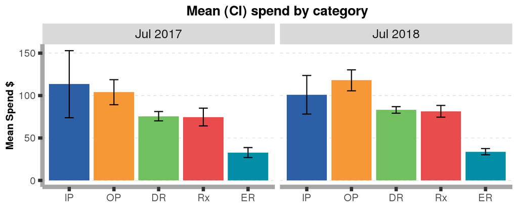

$\hspace{0in}$ Figure 5. Mean spending by service types

The PMPM dollar amounts from the current month July of the year back to July month of the prior year were also calculated to compare the spending for the different services over the one year period.

Table 10. PMPM $ spending for each group

| Group | Months | IP | OP | DR | Rx | ER | Total | Members |
| --- | --- | --- | --- | --- | --- | --- | --- | --- |
| Group 1 | 77,591 | 97.1 | 118.2 | 82.3 | 68.9 | 30.5 | 397.0 | 14,071 |
| Group 2 | 246,033 | 107.2 | 124.8 | 89.3 | 82.3 | 29.9 | 433.3 | 36,438 |

Table 11 shows that after adjusting for inflation in 2018, the healthcare costs are not statistically different between the members eligible in July 2017 and in July 2018.

Table 11. Comparison of healthcare $ spending (adjusted for inflation)

|  | July 2017 (N=14071) | July 2018 (N=36438) | p value |
| --- | --- | --- | --- |
| **IP** |  |  | 0.518 |
| Mean (SD) | 115.53 (2438.24) | 100.92 (2215.64) |  |
| Range | 0.00 - 170953.35 | 0.00 - 135134.21 |  |
| **OP** |  |  | 0.284 |
| Mean (SD) | 105.91 (910.51) | 117.93 (1204.90) |  |
| Range | 0.00 - 22813.84 | 0.00 - 47591.66 |  |
| **DR** |  |  | 0.101 |
| Mean (SD) | 77.09 (339.91) | 83.04 (375.35) |  |
| Range | 0.00 - 14223.24 | 0.00 - 17708.18 |  |
| **Rx** |  |  | 0.416 |
| Mean (SD) | 76.08 (645.69) | 81.45 (673.22) |  |
| Range | 0.00 - 31970.11 | 0.00 - 43389.15 |  |
| **ER** |  |  | 0.913 |
| Mean (SD) | 33.45 (361.92) | 33.83 (356.76) |  |
| Range | 0.00 - 11957.57 | 0.00 - 14119.08 |  |
| **Total** |  |  | 0.749 |
| Mean (SD) | 408.04 (2898.99) | 417.12 (2849.43) |  |
| Range | 0.00 - 170953.35 | 0.00 - 136078.69 |  |

Table 12. Eligible Count and Total Spend (adjusted for inflation)

| Year_Mo_ | N | Mean Total Spend | SD Total Spend |
| --- | --- | --- | --- |
| Jul 2017 | 14,071 | 408.0 | 2,899.0 |
| Jul 2018 | 36,438 | 417.1 | 2,849.4 |

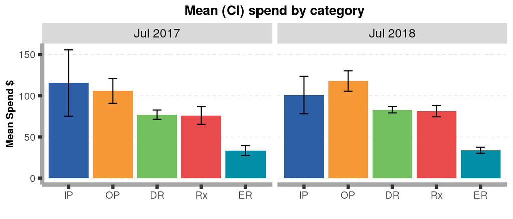

$\hspace{0in}$ Figure 6. Mean spending by service types

## Enrolled

### Demographics

Table 13. Demographics profile of those who were enrolled for Key Account motion program

|  | July 2017 (N=9730) | July 2018 (N=16672) | p value |
| --- | --- | --- | --- |
| **Age** |  |  | < 0.001 |
| Median (Q1, Q3) | 44.00 (35.00, 54.00) | 43.00 (34.00, 53.00) |  |
| Mean (SD) | 44.16 (11.46) | 43.28 (11.41) |  |
| Range | 19.00 - 77.00 | 19.00 - 81.00 |  |
| **Gender** |  |  | < 0.001 |
| N-Miss | 0 | 1 |  |
| F | 4711 (48.4%) | 8755 (52.5%) |  |
| M | 5019 (51.6%) | 7916 (47.5%) |  |
| **Subscriber** | 7672 (78.8%) | 13708 (82.2%) | < 0.001 |
| **Area** |  |  | < 0.001 |
| N-Miss | 21 | 19 |  |
| U | 3012 (31.0%) | 5358 (32.2%) |  |
| S | 4130 (42.5%) | 7770 (46.7%) |  |
| R | 2567 (26.4%) | 3525 (21.2%) |  |
| **Median Household Income** |  |  | < 0.001 |
| N-Miss | 23 | 23 |  |
| Median (Q1, Q3) | 55630.00 (44022.50, 73767.00) | 57348.00 (44638.00, 74970.00) |  |
| Mean (SD) | 60887.56 (22951.85) | 62110.92 (23603.52) |  |
| Range | 11021.00 - 217171.00 | 11021.00 - 250001.00 |  |

Table 14. Effect size of the difference

[output not shown]

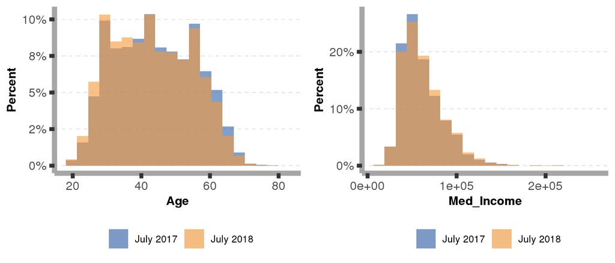

$\hspace{0in}$ Figure 7. Distribution of age and median household income

### Health

Prevalence of disease conditions do not differ between the two groups of enrolled members. However, the RAF scores of enrolled members in July 2018 is 9.9 percent lower than those enrolled in July 2017. The effect size is 0.055, a negligible estimate.

Table 15. RAF score and percentage prevalence

|  | July 2017 (N=9730) | July 2018 (N=16672) | p value |
| --- | --- | --- | --- |
| **Type 2 Diabetes** | 54 (0.6%) | 96 (0.6%) | 0.828 |
| **Hypertension** | 250 (2.6%) | 458 (2.7%) | 0.388 |
| **Depression / Anxiety** | 167 (1.7%) | 305 (1.8%) | 0.504 |
| **COPD** | 12 (0.1%) | 13 (0.1%) | 0.248 |
| **CHF** | 2 (0.0%) | 11 (0.1%) | 0.108 |
| **RA** | 3 (0.0%) | 9 (0.1%) | 0.395 |
| **Chronic Pain** | 349 (3.6%) | 612 (3.7%) | 0.725 |
| **RAF Score** |  |  | 0.012 |
| N-Miss | 0 | 1 |  |
| Median (Q1, Q3) | 0.49 (0.29, 0.70) | 0.49 (0.30, 0.70) |  |
| Mean (SD) | 1.21 (4.09) | 1.09 (3.55) |  |
| Range | 0.14 - 185.14 | 0.14 - 185.14 |  |

We considered looking at the disease prevalence and RAF scores of the continuously enrolled members. Interestingly, the table below shows the RAF scores of tenured members do not differ between the two groups.

Table 16. RAF score of continuously UHC enrolled members

|  | July 2017 (N=640) | July 2018 (N=5983) | p value |
| --- | --- | --- | --- |
| **RAF Score** |  |  | 0.620 |
| Median (Q1, Q3) | 0.48 (0.29, 0.70) | 0.55 (0.29, 0.73) |  |
| Mean (SD) | 1.40 (4.18) | 1.31 (4.50) |  |
| Range | 0.14 - 54.55 | 0.14 - 185.14 |  |

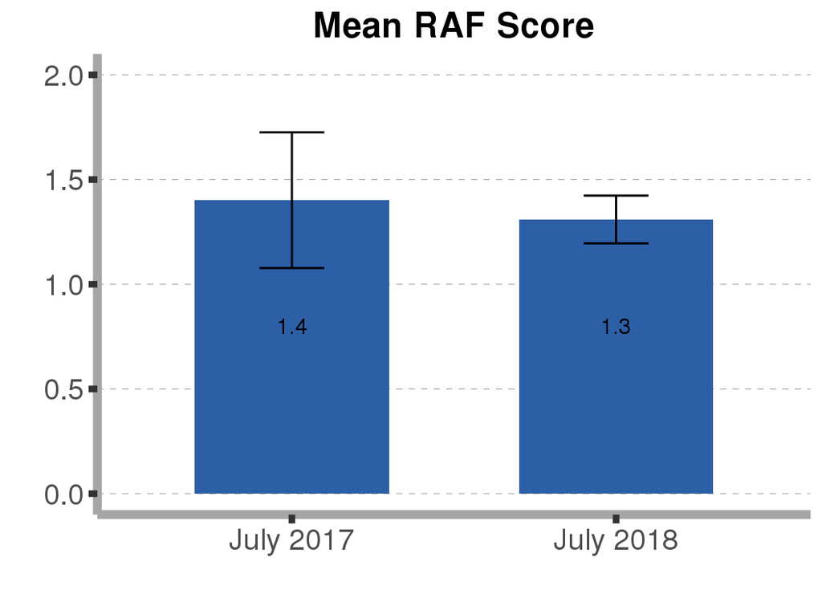

$\hspace{0in}$ Figure 8. Mean (confidence interval) of RAF score

Below table looks at the disease prevalence of motion enrolled members who were continuously enrolled in UHC plans from January to July of the year. The prevalence of hypertension, depression or anxiety, and chronic pain conditions are higher among those enrolled in July 2018 than those enrolled in July 2017 by 1%, 1%, and 1.2%, respectively (Table 17). However, cohen’s h suggest that these differences are so small (Table 18).

Table 17. Jan - July percentage prevalence

|  | July 2017 (N=9730) | July 2018 (N=16672) | p value |
| --- | --- | --- | --- |
| **Type 2 Diabetes** | 54 (0.6%) | 96 (0.6%) | 0.828<sup>1</sup> |
| **Hypertension** | 905 (9.3%) | 1725 (10.3%) | 0.006<sup>1</sup> |
| **Depression / Anxiety** | 610 (6.3%) | 1209 (7.3%) | 0.002<sup>1</sup> |
| **COPD** | 46 (0.5%) | 73 (0.4%) | 0.683<sup>1</sup> |
| **CHF** | 12 (0.1%) | 32 (0.2%) | 0.187<sup>1</sup> |
| **RA** | 14 (0.1%) | 26 (0.2%) | 0.808<sup>1</sup> |
| **Chronic Pain** | 1054 (10.8%) | 2007 (12.0%) | 0.003<sup>1</sup> |

1. Pearson’s Chi-squared test

Table 18. Effect size of the difference

| Variable | Estimate | Magnitude |
| --- | --- | --- |
| Hypertension | 0.035 | negligible |
| Depression / Anxiety | 0.039 | negligible |
| Chronic pain | 0.038 | negligible |

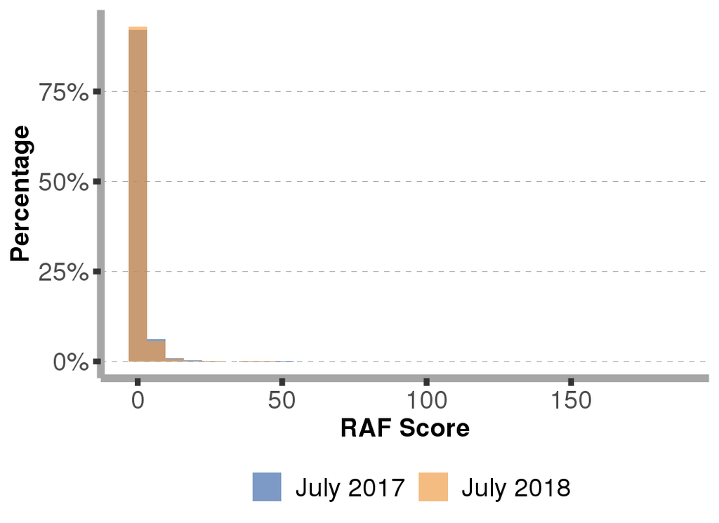

$\hspace{0in}$ Figure 9. RAF score distribution

### Claims

Table 19. Comparison of healthcare $ spending

|  | July 2017 (N=9730) | July 2018 (N=16672) | p value |
| --- | --- | --- | --- |
| **IP** |  |  | 0.498 |
| Mean (SD) | 95.79 (1775.13) | 80.94 (1685.29) |  |
| Range | 0.00 - 98023.72 | 0.00 - 85843.40 |  |
| **OP** |  |  | 0.146 |
| Mean (SD) | 101.52 (882.46) | 122.47 (1250.58) |  |
| Range | 0.00 - 19968.17 | 0.00 - 47591.66 |  |
| **DR** |  |  | 0.037 |
| Mean (SD) | 76.03 (322.26) | 85.19 (357.15) |  |
| Range | 0.00 - 8855.84 | 0.00 - 17708.18 |  |
| **Rx** |  |  | 0.595 |
| Mean (SD) | 75.68 (638.64) | 79.68 (560.10) |  |
| Range | 0.00 - 25119.36 | 0.00 - 23634.49 |  |
| **ER** |  |  | 0.518 |
| Mean (SD) | 32.16 (351.43) | 29.33 (337.69) |  |
| Range | 0.00 - 10550.58 | 0.00 - 10552.80 |  |
| **Total** |  |  | 0.589 |
| Mean (SD) | 381.16 (2345.27) | 397.61 (2414.21) |  |
| Range | 0.00 - 100693.77 | 0.00 - 86386.23 |  |

Table 20. Effect size of the difference

| Spend | Observed Difference | Percentage Difference | Estimate | Magnitude |
| --- | --- | --- | --- | --- |
| DR | 9.16 | 12.04 | 0.03 | negligible |

Table 21. Enrolled Count and Total Spend

| Year_Mo_ | N | Mean Total Spend | SD Total Spend |
| --- | --- | --- | --- |
| Jul 2017 | 9,730 | 381.2 | 2,345.3 |
| Jul 2018 | 16,672 | 397.6 | 2,414.2 |

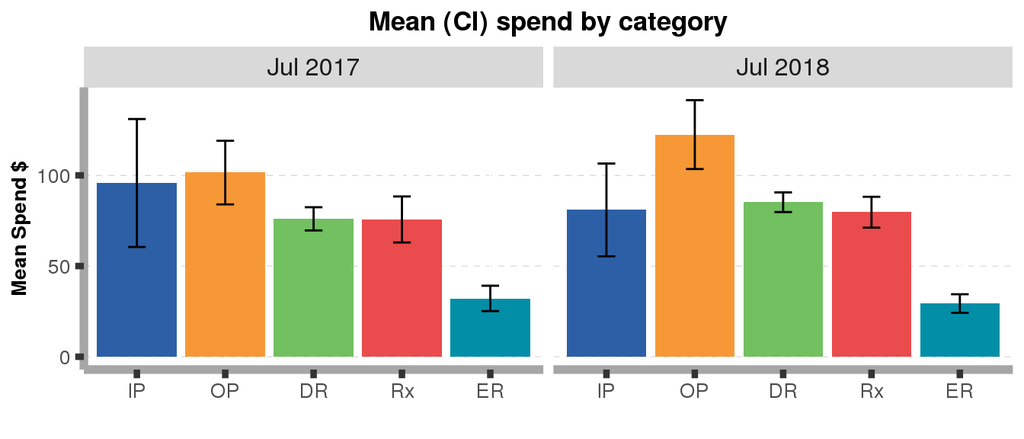

$\hspace{0in}$ Figure 10. Mean spending by service types

The PMPM dollar amounts from the curent month July of the year back to July month of the prior year were also calculated to compare the spending for the different services over the one year period.

Table 22. PMPM $ spending for each group

| Group | Months | IP | OP | DR | Rx | ER | Total | Members |
| --- | --- | --- | --- | --- | --- | --- | --- | --- |
| July 2017 | 53,442 | 80.1 | 106 | 78.9 | 68.3 | 28.0 | 361.3 | 9,730 |
| July 2018 | 136,075 | 95.4 | 125 | 90.8 | 81.5 | 26.9 | 419.6 | 16,672 |

Table 23 shows that after adjusting for inflation in 2018, the healthcare costs are not statistically different between the members enrolled in July 2017 and in July 2018.

Table 23. Comparison of healthcare $ spending (adjusted for inflation)

|  | July 2017 (N=9730) | July 2018 (N=16672) | p value |
| --- | --- | --- | --- |
| **IP** |  |  | 0.451 |
| Mean (SD) | 97.61 (1808.85) | 80.94 (1685.29) |  |
| Range | 0.00 - 99886.17 | 0.00 - 85843.40 |  |
| **OP** |  |  | 0.189 |
| Mean (SD) | 103.45 (899.22) | 122.47 (1250.58) |  |
| Range | 0.00 - 20347.57 | 0.00 - 47591.66 |  |
| **DR** |  |  | 0.081 |
| Mean (SD) | 77.48 (328.38) | 85.19 (357.15) |  |
| Range | 0.00 - 9024.10 | 0.00 - 17708.18 |  |
| **Rx** |  |  | 0.735 |
| Mean (SD) | 77.12 (650.77) | 79.68 (560.10) |  |
| Range | 0.00 - 25596.63 | 0.00 - 23634.49 |  |
| **ER** |  |  | 0.435 |
| Mean (SD) | 32.77 (358.10) | 29.33 (337.69) |  |
| Range | 0.00 - 10751.04 | 0.00 - 10552.80 |  |
| **Total** |  |  | 0.764 |
| Mean (SD) | 388.40 (2389.83) | 397.61 (2414.21) |  |
| Range | 0.00 - 102606.95 | 0.00 - 86386.23 |  |

Table 24. Eligible Count and Total Spend (adjusted for inflation)

| Year_Mo_ | N | Mean Total Spend | SD Total Spend |
| --- | --- | --- | --- |
| Jul 2017 | 9,730 | 388.4 | 2,389.8 |
| Jul 2018 | 16,672 | 397.6 | 2,414.2 |

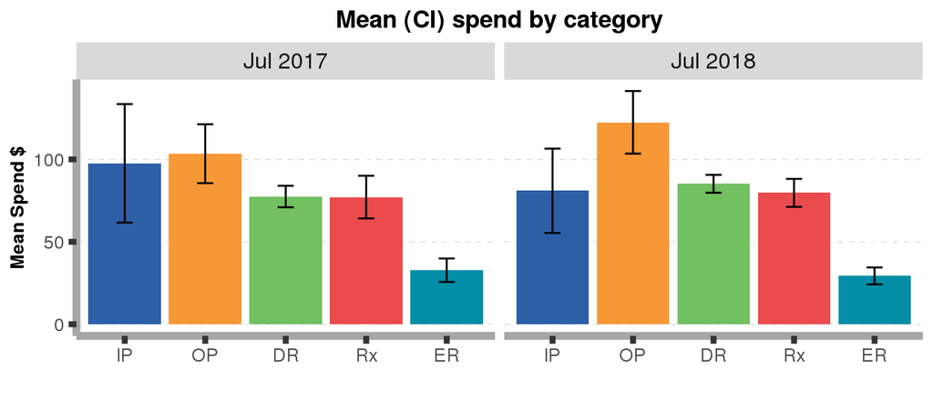

$\hspace{0in}$ Figure 11. Mean spending by service types

## Active

### Among Eligible

Table 25. Active Rate of Current Month and Current Month Year Ago

| Year Month | Active | Inactive | Active Rate % |
| --- | --- | --- | --- |
| July 2017 | 6775 | 7296 | 48.15 |
| July 2018 | 8884 | 27554 | 24.38 |

##### Demographics

The demographics of active among eligible groups are completely different (Table 26). Compared to July 2017 active among eligible members, July 2018 active eligible members are one-year younger, more females are observed than males, more subscribers are active, the percentage active from Suburban and Urban increases, median income also increases. Although these difference of the two groups has been proven to be statistically significant, the effect size suggests that the differences are negligible (Effect Size Tables).

Table 26. Demographics profile of those active among eligible

|  | July 2017 (N=6775) | July 2018 (N=8884) | p value |
| --- | --- | --- | --- |
| **Age** |  |  | < 0.01 |
| Mean (SD) | 45.09 (11.28) | 44.55 (11.10) |  |
| Range | 19.00 - 77.00 | 19.00 - 78.00 |  |
| **Gender** |  |  | < 0.01 |
| N-Miss | 0 | 1 |  |
| F | 3282 (48.4%) | 4809 (54.1%) |  |
| M | 3493 (51.6%) | 4074 (45.9%) |  |
| **Subscriber** |  |  | < 0.01 |
| 0 | 1406 (20.8%) | 1577 (17.8%) |  |
| 1 | 5369 (79.2%) | 7307 (82.2%) |  |
| **Area** |  |  | < 0.01 |
| N-Miss | 13 | 6 |  |
| R | 1728 (25.6%) | 1759 (19.8%) |  |
| S | 2881 (42.6%) | 4259 (48.0%) |  |
| U | 2153 (31.8%) | 2860 (32.2%) |  |
| **Median Income** |  |  | < 0.01 |
| N-Miss | 14 | 8 |  |
| Mean (SD) | 61299.64 (22992.82) | 63282.93 (23838.75) |  |
| Range | 11021.00 - 217171.00 | 11021.00 - 217171.00 |  |

Table 27. Effect size estimates of demographics

| Variable | Observed Difference | Estimate | Magnitude |
| --- | --- | --- | --- |
| Gender F | -0.057 | 0.114 | negligible |
| Gender M | 0.057 | 0.114 | negligible |
| Subscriber 1 | -0.030 | 0.076 | negligible |
| Area R | 0.057 | 0.137 | negligible |
| Area S | -0.054 | 0.108 | negligible |
| Area U | -0.004 | 0.008 | negligible |
| Age | 0.540 | 0.049 | negligible |
| Median Income | -1983.290 | 0.084 | negligible |

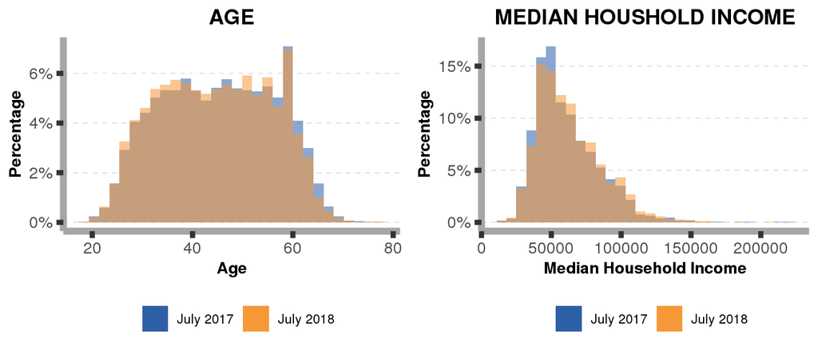

##### Health

It seems that there is no difference between the two groups in terms of disease conditions but theres is a difference in RAF score. RAF score decreased from 1.22 of current month year ago to 1.06 in current month however, this difference is negligible according to Hedges’g test. Also, conditions of July 2018 members is the same with July 2017 members. In addition to the condition comparison, we suspected that conditions might be recorded from the previous months (Jan-Jul of either year) since the members from the current month might never had any claims update. Once the member is flag in the months between January to July, he or she have that certain condition. In result, **hypertension**, **depression or anxiety**, and **chronic pain** are the conditions that the two groups differs. The percentage of active eligible members who have these conditions increased in the current month group however, these differences from current month year ago is negligible.

Table 28. RAF score and percentage prevalence comparisons

|  | July 2017 (N=6775) | July 2018 (N=8884) | p value |
| --- | --- | --- | --- |
| **Type 2 Diabetes** | 35 (0.5%) | 45 (0.5%) | 0.93 |
| **Hypertension** | 187 (2.8%) | 249 (2.8%) | 0.87 |
| **Depression and Anxiety** | 105 (1.5%) | 157 (1.8%) | 0.29 |
| **COPD** | 8 (0.1%) | 7 (0.1%) | 0.43 |
| **Congestive Heart Failure** | 1 (0.0%) | 3 (0.0%) | 0.46 |
| **Rheumatoid Athritis** | 2 (0.0%) | 3 (0.0%) | 0.88 |
| **Chronic Pain** | 250 (3.7%) | 315 (3.5%) | 0.63 |
| **RAF Score** |  |  | 0.01 |
| N-Missing | 0 | 1 |  |
| Median (Q1, Q3) | 0.55 (0.30, 0.73) | 0.55 (0.30, 0.70) |  |
| Mean (SD) | 1.22 (4.26) | 1.06 (3.55) |  |
| Range | 0.14 - 185.14 | 0.14 - 185.14 |  |

Table 29. Effect size estimate of RAF score

| Variable | Observed Difference | Estimate | Magnitude |
| --- | --- | --- | --- |
| RAF Score | 0.16 | 0.04 | negligible |

Table 30. Jan - July percentage prevalence comparisons

|  | July 2017 (N=6775) | July 2018 (N=8884) | p value |
| --- | --- | --- | --- |
| **Type 2 Diabetes** | 35 (0.5%) | 45 (0.5%) | 0.93 |
| **Hypertension** | 656 (9.7%) | 961 (10.8%) | 0.02 |
| **Depression and Anxiety** | 377 (5.6%) | 572 (6.4%) | 0.02 |
| **COPD** | 27 (0.4%) | 36 (0.4%) | 0.95 |
| **Congestive Heart Failure** | 7 (0.1%) | 14 (0.2%) | 0.36 |
| **Rheumatoid Athritis** | 8 (0.1%) | 7 (0.1%) | 0.43 |
| **Chronic Pain** | 694 (10.2%) | 1012 (11.4%) | 0.02 |

Table 31. Effect size estimate of conditions

| Variable | Observed Difference | Estimate | Magnitude |
| --- | --- | --- | --- |
| Hypertension | 0 | 0 | negligible |
| Depression and Anxiety | 0 | 0 | negligible |
| Chronic Pain | 0 | 0 | negligible |

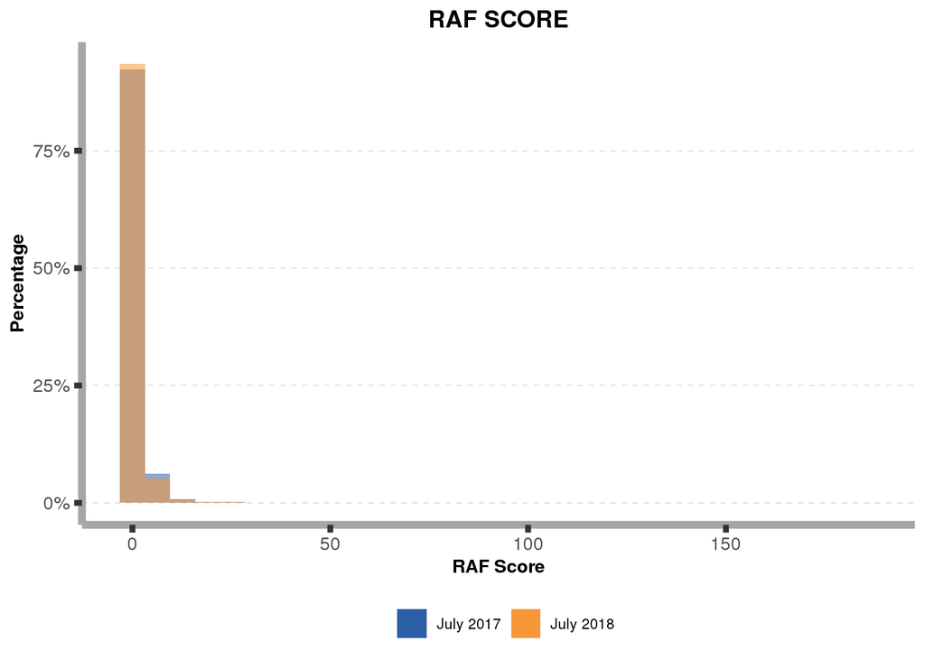

For people who are continuously enrolled in UHC, there is no difference in RAF Score between the two groups.

Table 32. RAF score comparisons among continuously enrolled in UHC

|  | July 2017 (N=436) | July 2018 (N=2868) | p value |
| --- | --- | --- | --- |
| **RAF Score** |  |  | 0.604 |
| Median (Q1, Q3) | 0.550 (0.300, 0.730) | 0.580 (0.370, 0.730) |  |
| Mean (SD) | 1.410 (4.076) | 1.286 (4.715) |  |
| Range | 0.140 - 49.560 | 0.140 - 185.140 |  |

Table 33. RAF score comparisons among continuously enrolled in UHC

|  | July 2017 (N=436) | July 2018 (N=2868) | p value |
| --- | --- | --- | --- |
| **RAF Score** |  |  | 0.604 |
| Median (Q1, Q3) | 0.550 (0.300, 0.730) | 0.580 (0.370, 0.730) |  |
| Mean (SD) | 1.410 (4.076) | 1.286 (4.715) |  |
| Range | 0.140 - 49.560 | 0.140 - 185.140 |  |

##### Claims

Table 34. Claims spending comparison

|  | July 2017 (N=6775) | July 2018 (N=8884) | p value |
| --- | --- | --- | --- |
| **IP** |  |  | 0.10 |
| Median (Q1, Q3) | 0.00 (0.00, 0.00) | 0.00 (0.00, 0.00) |  |
| Mean (SD) | 97.24 (1910.22) | 55.37 (1224.18) |  |
| Range | 0.00 - 98023.72 | 0.00 - 46551.66 |  |
| **OP** |  |  | 0.03 |
| Median (Q1, Q3) | 0.00 (0.00, 0.00) | 0.00 (0.00, 0.00) |  |
| Mean (SD) | 95.75 (851.16) | 136.40 (1378.75) |  |
| Range | 0.00 - 17155.84 | 0.00 - 47591.66 |  |
| **DR** |  |  | < 0.01 |
| Median (Q1, Q3) | 0.00 (0.00, 0.00) | 0.00 (0.00, 57.75) |  |
| Mean (SD) | 74.92 (325.47) | 91.68 (407.57) |  |
| Range | 0.00 - 8855.84 | 0.00 - 17708.18 |  |
| **RX** |  |  | 0.69 |
| Median (Q1, Q3) | 0.00 (0.00, 14.64) | 0.00 (0.00, 16.79) |  |
| Mean (SD) | 84.20 (733.51) | 80.10 (553.93) |  |
| Range | 0.00 - 25119.36 | 0.00 - 17277.41 |  |
| **ER** |  |  | 0.21 |
| Median (Q1, Q3) | 0.00 (0.00, 0.00) | 0.00 (0.00, 0.00) |  |
| Mean (SD) | 29.86 (324.67) | 23.51 (310.78) |  |
| Range | 0.00 - 7972.22 | 0.00 - 10552.80 |  |
| **Total Allowed Amount** |  |  | 0.89 |
| Median (Q1, Q3) | 0.00 (0.00, 122.36) | 0.00 (0.00, 150.15) |  |
| Mean (SD) | 381.94 (2417.31) | 387.05 (2180.48) |  |
| Range | 0.00 - 100693.77 | 0.00 - 66226.70 |  |

Table 35. Claims spending comparison (adjusted by 2018 inflation)

|  | July 2017 (N=6775) | July 2018 (N=8884) | p value |
| --- | --- | --- | --- |
| **IP** |  |  | 0.09 |
| Median (Q1, Q3) | 0.00 (0.00, 0.00) | 0.00 (0.00, 0.00) |  |
| Mean (SD) | 99.09 (1946.52) | 55.37 (1224.18) |  |
| Range | 0.00 - 99886.17 | 0.00 - 46551.66 |  |
| **OP** |  |  | 0.04 |
| Median (Q1, Q3) | 0.00 (0.00, 0.00) | 0.00 (0.00, 0.00) |  |
| Mean (SD) | 97.57 (867.33) | 136.40 (1378.75) |  |
| Range | 0.00 - 17481.80 | 0.00 - 47591.66 |  |
| **DR** |  |  | 0.01 |
| Median (Q1, Q3) | 0.00 (0.00, 0.00) | 0.00 (0.00, 57.75) |  |
| Mean (SD) | 76.34 (331.65) | 91.68 (407.57) |  |
| Range | 0.00 - 9024.10 | 0.00 - 17708.18 |  |
| **RX** |  |  | 0.58 |
| Median (Q1, Q3) | 0.00 (0.00, 14.91) | 0.00 (0.00, 16.79) |  |
| Mean (SD) | 85.80 (747.45) | 80.10 (553.93) |  |
| Range | 0.00 - 25596.63 | 0.00 - 17277.41 |  |
| **ER** |  |  | 0.18 |
| Median (Q1, Q3) | 0.00 (0.00, 0.00) | 0.00 (0.00, 0.00) |  |
| Mean (SD) | 30.43 (330.83) | 23.51 (310.78) |  |
| Range | 0.00 - 8123.69 | 0.00 - 10552.80 |  |
| **Total Allowed Amount** |  |  | 0.95 |
| Median (Q1, Q3) | 0.00 (0.00, 124.68) | 0.00 (0.00, 150.15) |  |
| Mean (SD) | 389.20 (2463.23) | 387.05 (2180.48) |  |
| Range | 0.00 - 102606.95 | 0.00 - 66226.70 |  |

Table 36. Effect size estimates of claims spending

| Variable | Observed Difference | Estimate | Magnitude |
| --- | --- | --- | --- |
| OP | -40.65 | 0.034 | negligible |
| DR | -16.76 | 0.045 | negligible |

Table 37. Per member per month claims spending

| Year Month | PMPM ($) |
| --- | --- |
| July 2017 | 331.0312 |
| July 2018 | 385.6273 |

Table 38. Per member per month claims spending (adjusted by 2018 inflation)

| Year Month | PMPM ($) |
| --- | --- |
| July 2017 | 337.3208 |
| July 2018 | 385.6273 |

Table 39. Bootstrap on the difference in total PMPM costs

| OBSERVED DIFFERENCE | 95% CI |
| --- | --- |
| 54.5961 | ( 6.17 , 101.45 ) |

Table 40. Bootstrap on the difference in total PMPM costs (adjusted by 2018 inflation)

| OBSERVED DIFFERENCE | 95% CI |
| --- | --- |
| 48.30651 | ( 1.65 , 94.38 ) |

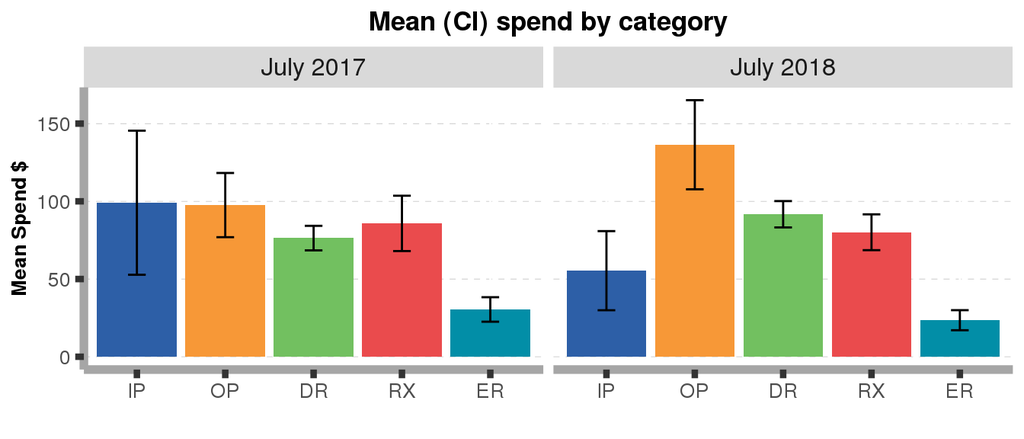

$\hspace{0in}$ Figure 12. Mean spending by service types

### Among Enrolled

Table 41. Active rate of current month and current month year ago

| Year Month | Active | Inactive | Active Rate % |
| --- | --- | --- | --- |
| July 2017 | 6772 | 2958 | 69.60 |
| July 2018 | 8880 | 7792 | 53.26 |

##### Demographics

There is also differences in the demographics between the two groups of members who are active among enrolled however, the differences are negligible base in Hedges’ g and cohen’s H tests.

Table 42. Demographics profile of those active among enrolled

|  | July 2017 (N=6772) | July 2018 (N=8880) | p value |
| --- | --- | --- | --- |
| **Age** |  |  | < 0.01 |
| Mean (SD) | 45.10 (11.28) | 44.55 (11.11) |  |
| Range | 19.00 - 77.00 | 19.00 - 78.00 |  |
| **Gender** |  |  | < 0.01 |
| N-Miss | 0 | 1 |  |
| F | 3282 (48.5%) | 4807 (54.1%) |  |
| M | 3490 (51.5%) | 4072 (45.9%) |  |
| **Subscriber** |  |  | < 0.01 |
| 0 | 1406 (20.8%) | 1576 (17.7%) |  |
| 1 | 5366 (79.2%) | 7304 (82.3%) |  |
| **Area** |  |  | < 0.01 |
| N-Miss | 13 | 6 |  |
| R | 1727 (25.6%) | 1758 (19.8%) |  |
| S | 2879 (42.6%) | 4258 (48.0%) |  |
| U | 2153 (31.9%) | 2858 (32.2%) |  |
| **Median Income** |  |  | < 0.01 |
| N-Miss | 14 | 8 |  |
| Mean (SD) | 61303.21 (22996.16) | 63288.62 (23839.85) |  |
| Range | 11021.00 - 217171.00 | 11021.00 - 217171.00 |  |

Table 43. Effect size estimates of demographics

| Variable | Observed Difference | Estimate | Magnitude |
| --- | --- | --- | --- |
| Gender F | -0.057 | 0.114 | negligible |
| Gender M | 0.057 | 0.114 | negligible |
| Subscriber 1 | -0.030 | 0.076 | negligible |
| Area R | 0.057 | 0.137 | negligible |
| Area S | -0.054 | 0.108 | negligible |
| Area U | -0.004 | 0.008 | negligible |
| Age | 0.540 | 0.049 | negligible |
| Median Income | -1983.290 | 0.084 | negligible |

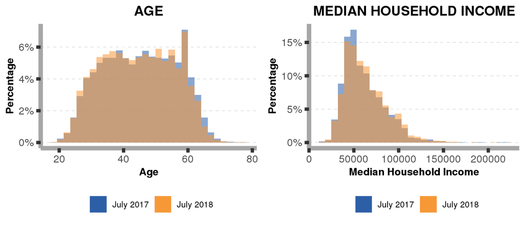

##### Health

Prevalence of disease conditions hypertension, depression or anxiety, and chronic pain are different in both groups, however the difference is negligible. RAF score is also different between the two groups. RAF score for members in July 2018 is smaller than RAF score in July 2017.

Table 44. RAF score and percentage prevalence comparisons

|  | July 2017 (N=6772) | July 2018 (N=8880) | p value |
| --- | --- | --- | --- |
| **Type 2 Diabetes** | 35 (0.5%) | 45 (0.5%) | 0.93 |
| **Hypertension** | 187 (2.8%) | 249 (2.8%) | 0.87 |
| **Depression and Anxiety** | 105 (1.6%) | 157 (1.8%) | 0.29 |
| **COPD** | 8 (0.1%) | 7 (0.1%) | 0.43 |
| **Congestive Heart Failure** | 1 (0.0%) | 3 (0.0%) | 0.46 |
| **Rheumatoid Athritis** | 2 (0.0%) | 3 (0.0%) | 0.88 |
| **Chronic Pain** | 250 (3.7%) | 315 (3.5%) | 0.63 |
| **RAF Score** |  |  | 0.01 |
| N-Missing | 0 | 1 |  |
| Median (Q1, Q3) | 0.55 (0.30, 0.73) | 0.55 (0.30, 0.70) |  |
| Mean (SD) | 1.22 (4.26) | 1.06 (3.55) |  |
| Range | 0.14 - 185.14 | 0.14 - 185.14 |  |

Table 45. Effect size estimate of RAF score

| Variable | Observed Difference | Estimate | Magnitude |
| --- | --- | --- | --- |
| RAF Score | 0.16 | 0.04 | negligible |

Table 46. Jan-Jul percentage prevalence comparisons

|  | July 2017 (N=6772) | July 2018 (N=8880) | p value |
| --- | --- | --- | --- |
| **Type 2 Diabetes** | 35 (0.5%) | 45 (0.5%) | 0.93 |
| **Hypertension** | 656 (9.7%) | 961 (10.8%) | 0.02 |
| **Depression and Anxiety** | 377 (5.6%) | 572 (6.4%) | 0.02 |
| **COPD** | 27 (0.4%) | 36 (0.4%) | 0.95 |
| **Congestive Heart Failure** | 7 (0.1%) | 14 (0.2%) | 0.36 |
| **Rheumatoid Athritis** | 8 (0.1%) | 7 (0.1%) | 0.43 |
| **Chronic Pain** | 694 (10.2%) | 1012 (11.4%) | 0.02 |

Table 47. Effect size estimates of conditions

| Variable | Observed Difference | Estimate | Magnitude |
| --- | --- | --- | --- |
| Hypertension | 0 | 0 | negligible |
| Depression and Anxiety | 0 | 0 | negligible |
| Chronic Pain | 0 | 0 | negligible |

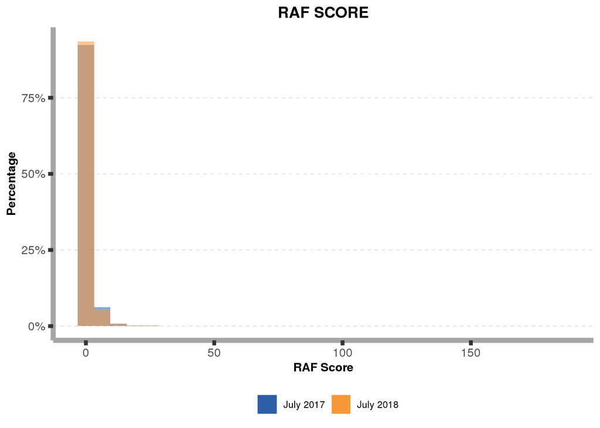

For people who are continuously enrolled in UHC, there is no difference in RAF Score between the two groups.

Table 48. RAF score comparisons among continuously enrolled in UHC

|  | July 2017 (N=436) | July 2018 (N=2866) | p value |
| --- | --- | --- | --- |
| **RAF Score** |  |  | 0.606 |
| Median (Q1, Q3) | 0.550 (0.300, 0.730) | 0.580 (0.370, 0.730) |  |
| Mean (SD) | 1.410 (4.076) | 1.287 (4.717) |  |
| Range | 0.140 - 49.560 | 0.140 - 185.140 |  |

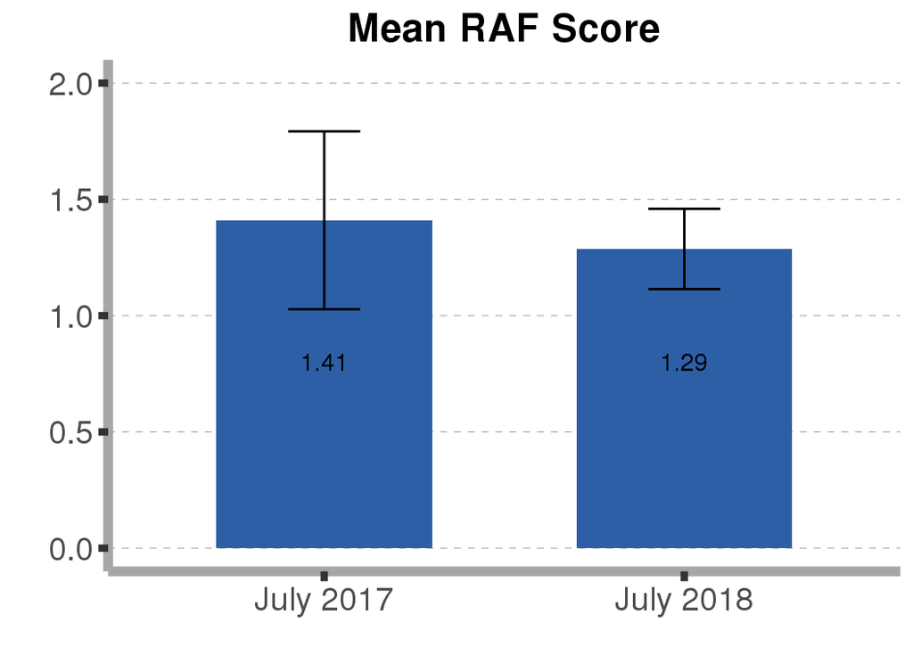

$\hspace{0in}$ Figure 13. Mean (confidence interval) of RAF score

##### Claims

Table 49. Claims spending comparison

|  | July 2017 (N=6772) | July 2018 (N=8880) | p value |
| --- | --- | --- | --- |
| **IP** |  |  | 0.10 |
| Median (Q1, Q3) | 0.00 (0.00, 0.00) | 0.00 (0.00, 0.00) |  |
| Mean (SD) | 97.29 (1910.64) | 55.40 (1224.46) |  |
| Range | 0.00 - 98023.72 | 0.00 - 46551.66 |  |
| **OP** |  |  | 0.03 |
| Median (Q1, Q3) | 0.00 (0.00, 0.00) | 0.00 (0.00, 0.00) |  |
| Mean (SD) | 95.79 (851.35) | 136.43 (1379.06) |  |
| Range | 0.00 - 17155.84 | 0.00 - 47591.66 |  |
| **DR** |  |  | < 0.01 |
| Median (Q1, Q3) | 0.00 (0.00, 0.00) | 0.00 (0.00, 57.90) |  |
| Mean (SD) | 74.95 (325.54) | 91.72 (407.66) |  |
| Range | 0.00 - 8855.84 | 0.00 - 17708.18 |  |
| **RX** |  |  | 0.69 |
| Median (Q1, Q3) | 0.00 (0.00, 14.65) | 0.00 (0.00, 16.80) |  |
| Mean (SD) | 84.24 (733.67) | 80.13 (554.06) |  |
| Range | 0.00 - 25119.36 | 0.00 - 17277.41 |  |
| **ER** |  |  | 0.21 |
| Median (Q1, Q3) | 0.00 (0.00, 0.00) | 0.00 (0.00, 0.00) |  |
| Mean (SD) | 29.87 (324.74) | 23.52 (310.85) |  |
| Range | 0.00 - 7972.22 | 0.00 - 10552.80 |  |
| **Total Allowed Amount** |  |  | 0.89 |
| Median (Q1, Q3) | 0.00 (0.00, 122.57) | 0.00 (0.00, 150.15) |  |
| Mean (SD) | 382.11 (2417.83) | 387.20 (2180.96) |  |
| Range | 0.00 - 100693.77 | 0.00 - 66226.70 |  |

Table 50. Claims spending comparison (adjusted by 2018 inflation)

|  | July 2017 (N=6772) | July 2018 (N=8880) | p value |
| --- | --- | --- | --- |
| **IP** |  |  | 0.09 |
| Median (Q1, Q3) | 0.00 (0.00, 0.00) | 0.00 (0.00, 0.00) |  |
| Mean (SD) | 99.13 (1946.95) | 55.40 (1224.46) |  |
| Range | 0.00 - 99886.17 | 0.00 - 46551.66 |  |
| **OP** |  |  | 0.04 |
| Median (Q1, Q3) | 0.00 (0.00, 0.00) | 0.00 (0.00, 0.00) |  |
| Mean (SD) | 97.61 (867.52) | 136.43 (1379.06) |  |
| Range | 0.00 - 17481.80 | 0.00 - 47591.66 |  |
| **DR** |  |  | 0.01 |
| Median (Q1, Q3) | 0.00 (0.00, 0.00) | 0.00 (0.00, 57.90) |  |
| Mean (SD) | 76.37 (331.72) | 91.72 (407.66) |  |
| Range | 0.00 - 9024.10 | 0.00 - 17708.18 |  |
| **RX** |  |  | 0.58 |
| Median (Q1, Q3) | 0.00 (0.00, 14.93) | 0.00 (0.00, 16.80) |  |
| Mean (SD) | 85.84 (747.61) | 80.13 (554.06) |  |
| Range | 0.00 - 25596.63 | 0.00 - 17277.41 |  |
| **ER** |  |  | 0.18 |
| Median (Q1, Q3) | 0.00 (0.00, 0.00) | 0.00 (0.00, 0.00) |  |
| Mean (SD) | 30.44 (330.91) | 23.52 (310.85) |  |
| Range | 0.00 - 8123.69 | 0.00 - 10552.80 |  |
| **Total Allowed Amount** |  |  | 0.95 |
| Median (Q1, Q3) | 0.00 (0.00, 124.90) | 0.00 (0.00, 150.15) |  |
| Mean (SD) | 389.37 (2463.77) | 387.20 (2180.96) |  |
| Range | 0.00 - 102606.95 | 0.00 - 66226.70 |  |

Table 51. Effect size estimates of claims spending

| Variable | Observed Difference | Estimate | Magnitude |
| --- | --- | --- | --- |
| OP | -40.65 | 0.034 | negligible |
| DR | -16.76 | 0.045 | negligible |

Table 52. Per member per month claims spending

| Year Month | PMPM ($) |
| --- | --- |
| July 2017 | 330.9293 |
| July 2018 | 385.8003 |

Table 53. Per member per month claims spending (adjusted by 2018 inflation)

| Year Month | PMPM ($) |
| --- | --- |
| July 2017 | 337.2170 |
| July 2018 | 385.8003 |

Table 54. Bootstrap on the difference in total PMPM costs

| OBSERVED DIFFERENCE | 95% CI |
| --- | --- |
| 54.87099 | ( 7.89 , 103.72 ) |

Table 55. Bootstrap on the difference in total PMPM costs(adjusted by 2018 inflation)

| OBSERVED DIFFERENCE | 95% CI |
| --- | --- |
| 48.58333 | ( 0.99 , 95.45 ) |

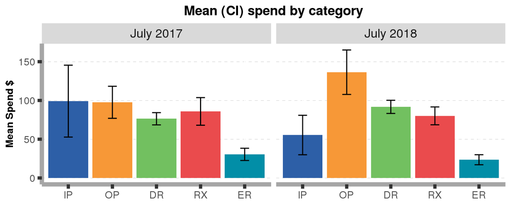

$\hspace{0in}$ Figure 14. Mean spending by service types

# Discussion

This grant tried to understand the enrollment rate drop in Key Accounts Motion program by comparing the characteristics that exist between the members in July 2017 and in July 2018. It specifically focuses on the comparisons of characteristics, particularly those related to health between those 1) eligible, 2) enrolled and 3) actively walking among those enrolled in July 2017 and in July 2018.

Eligible members in July 2018 have 4% more females, a year younger, located more in suburban areas and less in rural areas than those eligible members in July 2017. They cost more on doctor visits by about $8 or 10% higher, but the overall costs are the same between the two groups. The effect sizes suggest that the differences are negligible. Examining the health characteristics further, the RAF scores and prevalene of disease conditions of those having continuous enrollment with UHC do not differ between the two groups.

On the average, enrolled members in July 2018 have 4% more females, about a year younger, more suburbanites, have median household income $1,223 more than those enrolled in July 2017. July 2018 enrolled members have higher costs for doctor visits, but have the same costs for overall healthcare. RAF scores between the two groups do not differ when we considered one year continuous enrollment with UHC. Looking at January to July motion enrollment the prevalence of hypertension, depression or anxiety, and chronic pain conditions are higher among those enrolled in July 2018 than those in July 2017 by 1%, 1%, and 1.2%, respectively. The effect sizes suggest that the aforementioned differences are negligible. Health status comparison entails that we are not loosing the sick people in the motion program which supposed to be the ones engaged and active.

Generally speaking, there are no major differences in the types of people who are enrolling and engaging in the Key Accounts motion program.

The drop in motion program enrollment rate is really meaningful and needs to be addressed at the program level. The additional drop in people who are active also needs to be adresssed at the program level. It was observed that majority of the employers in July 2018 have zero enrollment rate in KA motion program and less percentage of the employers have their employees enrolled in the program. The spike at zero could be addressed more at the admin level of the companies while the waning middle distribution could be addressed at the employees level making sure that the corresponding addresses are updated. Better promotion and enrollment strategies could be utilized to bring back increase in enrollment and engagement rates of members.

# Appendix

| Group 1 counts of eligible per year month Year_Mo | Group 1 counts of eligible per year month N |
| --- | --- |
| 201607 | 941 |
| 201608 | 1017 |
| 201609 | 1360 |
| 201610 | 1629 |
| 201611 | 1877 |
| 201612 | 2007 |
| 201701 | 7531 |
| 201702 | 7737 |
| 201703 | 8071 |
| 201704 | 9544 |
| 201705 | 10723 |
| 201706 | 12635 |
| 201707 | 14071 |

| Group 2 counts of eligible per year month Year_Mo | Group 2 counts of eligible per year month N |
| --- | --- |
| 201707 | 11282 |
| 201708 | 12479 |
| 201709 | 12580 |
| 201710 | 13248 |
| 201711 | 13509 |
| 201712 | 13528 |
| 201801 | 24178 |
| 201802 | 24332 |
| 201803 | 25825 |
| 201804 | 27674 |
| 201805 | 29569 |
| 201806 | 31372 |
| 201807 | 36438 |